# TP BATS

```r
library(ggplot2)
library(corrplot)
bats <- read.table(file="bats.csv", sep=";", skip=3, header=T)
names(bats)
```

```
## [1] "Species" "Diet"    "Clade"   "BOW"     "BRW"     "AUD"     "MOB"
## [8] "HIP"
```

# Part 2: Study of the relationship between brain waeight and body mass

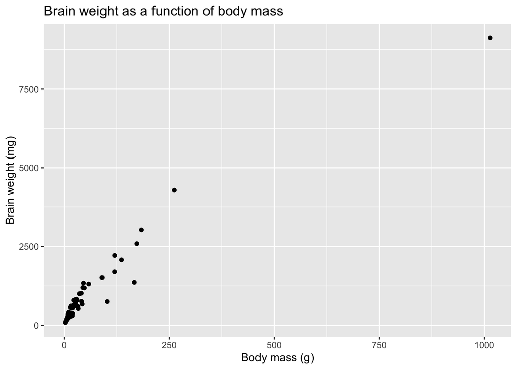

```r
phyto <- bats[(bats$Diet==1),]

ggplot(data = bats, aes(x=BOW, y=BRW)) +
  geom_point() +
  ggtitle("Brain weight as a function of body mass") +
  xlab("Body mass (g)") +
  ylab("Brain weight (mg)")
```

It’s weird there is a bat that is very huge compared to others

```r
reg <- lm(BRW ~BOW, data=phyto)
```

The mathematical model constructed by r is:
$$\begin{equation}
Y = \beta_0 + \beta_1 X
\end{equation}$$

```r
summary(reg)
```

```
##
## Call:
## lm(formula = BRW ~ BOW, data = phyto)
##
## Residuals:
##     Min      1Q  Median      3Q     Max
## -628.32 -233.94  -65.74  158.26 1308.59
##
## Coefficients:
##             Estimate Std. Error t value Pr(>|t|)
## (Intercept) 623.4469    81.4762   7.652 3.14e-08 ***
## BOW           8.9999     0.3972  22.659  < 2e-16 ***
## ---
## Signif. codes:  0 '***' 0.001 '**' 0.01 '*' 0.05 '.' 0.1 ' ' 1
##
## Residual standard error: 396.9 on 27 degrees of freedom
## Multiple R-squared:   0.95,  Adjusted R-squared:  0.9482
## F-statistic: 513.4 on 1 and 27 DF,  p-value: < 2.2e-16
```

The estimate of the intercept is `623.4469` the t-value for the significiancy of the correlation is `22.659` which corresponds to a p-value of `2e-16` meaning that we can reject the null hypothesis the null hypothesis is:
$$\begin{equation}
H_0: \beta_1 = 0
\end{equation}$$
We can say that the body mass of bats is positively correlated to their brain weight

The coefficient of determination $R^2$ has a value of `0.95`

```r
anova(reg)
```

```
## Analysis of Variance Table
##
## Response: BRW
##           Df   Sum Sq  Mean Sq F value    Pr(>F)
## BOW        1 80888380 80888380  513.42 < 2.2e-16 ***
## Residuals 27  4253838   157550
## ---
## Signif. codes:  0 '***' 0.001 '**' 0.01 '*' 0.05 '.' 0.1 ' ' 1
```

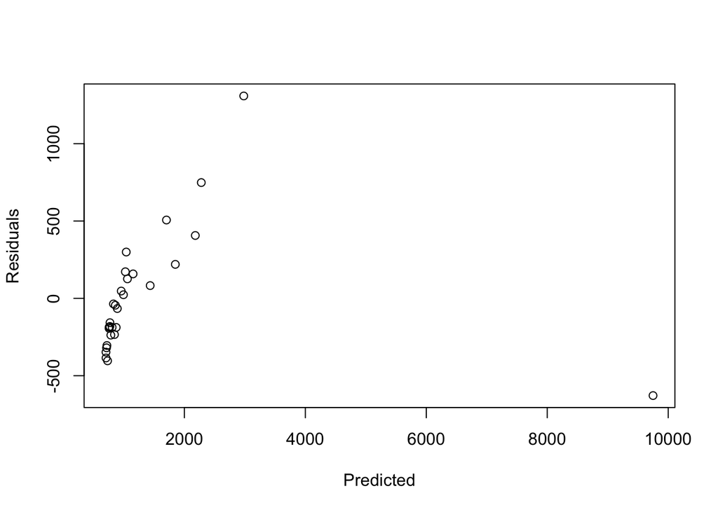

```r
plot(reg$fitted.values, reg$residuals, xlab="Predicted", ylab="Residuals")
```

We can see that all the predictions are squeezed in the left because of one single point far at `10000` mg. This leads to huge errors around `2000`

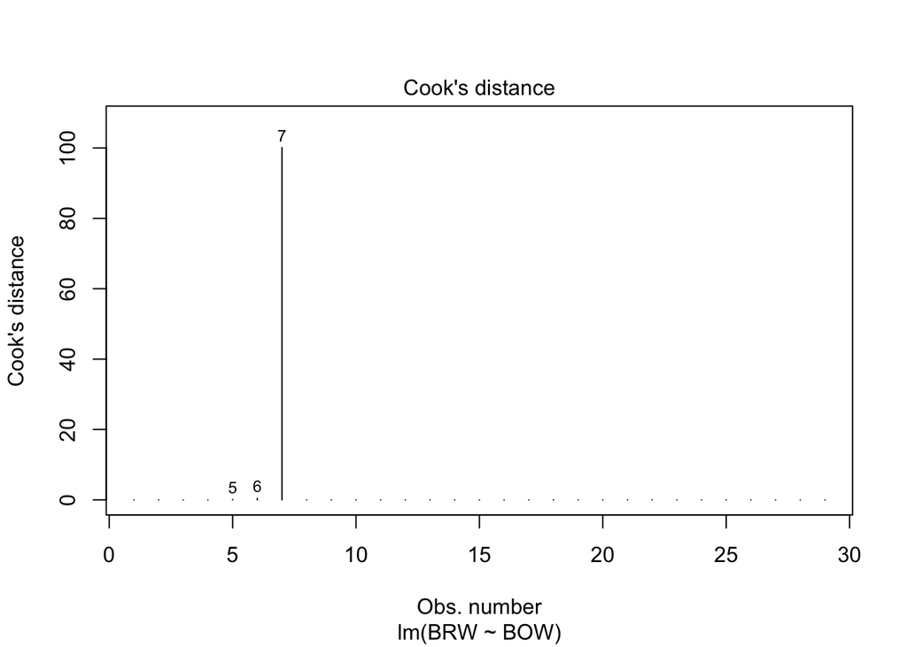

```r
plot(reg, 4)
```

```r
phytobis = phyto[which(phyto$BRW < 8000),]
reg2 <- lm(BRW ~ BOW, data=phytobis)
summary(reg2)
```

```
##
## Call:
## lm(formula = BRW ~ BOW, data = phytobis)
##
## Residuals:
##     Min      1Q  Median      3Q     Max
## -269.76  -93.33    8.73  112.93  322.55
##
## Coefficients:
##             Estimate Std. Error t value Pr(>|t|)
## (Intercept) 346.5452    35.4920   9.764 3.48e-10 ***
## BOW          14.5099     0.4285  33.860  < 2e-16 ***
## ---
## Signif. codes:  0 '***' 0.001 '**' 0.01 '*' 0.05 '.' 0.1 ' ' 1
##
## Residual standard error: 141.8 on 26 degrees of freedom
## Multiple R-squared:  0.9778, Adjusted R-squared:  0.977
## F-statistic:  1147 on 1 and 26 DF,  p-value: < 2.2e-16
```

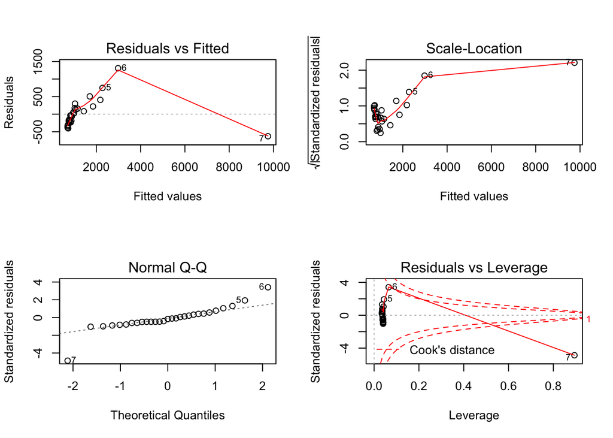

```r
par(mfcol=c(2, 2))
plot(reg)
```

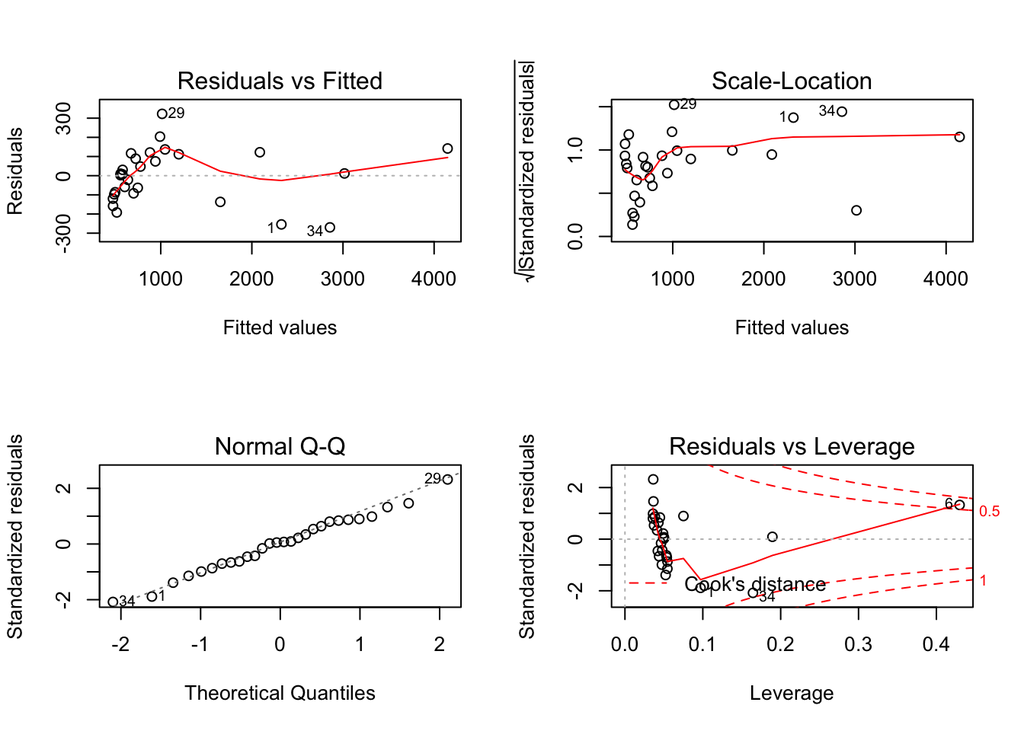

```r
par(mfcol=c(2, 2))
plot(reg2)
```

## First plot The second regression looks much better base on the y-scale of the residuals. But there is still some structure in the second one.

## Second plot

In the first regression, value of residuals grows with respect to the output value. Whereas in the second one, it’s almost flat in this way. As we don’t want this kind of strutures, the second would be preferable

## Third plot

The comparison between the theoretical quantiles and the normal law is also better for the second regression. In the first one, we see that several points are way off the theoretical line in the extremas. Whereas on the second one, they are much closer.

# Part 3, study of the contribution of parts of the brain to thr brain weight

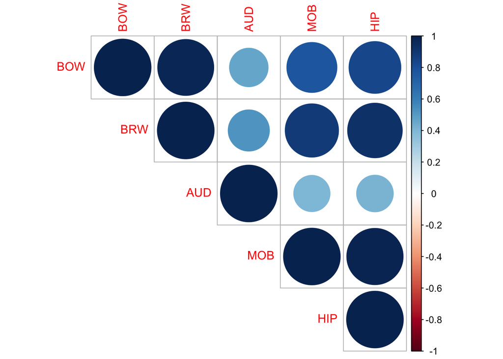

```r
phytoNum=phyto[, c(4:8)]
mat.cor = cor(phytoNum)
corrplot(mat.cor, type="upper")
```

```r
cor.test(phyto$BRW, phyto$HIP)
```

```
##
##  Pearson's product-moment correlation
##
## data:  phyto$BRW and phyto$HIP
## t = 12.91, df = 27, p-value = 4.574e-13
## alternative hypothesis: true correlation is not equal to 0
## 95 percent confidence interval:
##  0.8502663 0.9658107
## sample estimates:
##       cor
## 0.9276811
```

```r
cor.test(phyto$BRW, phyto$MOB)
```

```
##
##  Pearson's product-moment correlation
##
## data:  phyto$BRW and phyto$MOB
## t = 9.7964, df = 27, p-value = 2.203e-10
## alternative hypothesis: true correlation is not equal to 0
## 95 percent confidence interval:
##  0.7644185 0.9442114
## sample estimates:
##       cor
## 0.8834215
```

```r
cor.test(phyto$BRW, phyto$AUD)
```

```
##
##  Pearson's product-moment correlation
##
## data:  phyto$BRW and phyto$AUD
## t = 3.2338, df = 27, p-value = 0.003215
## alternative hypothesis: true correlation is not equal to 0
## 95 percent confidence interval:
##  0.2007495 0.7497021
## sample estimates:
##       cor
## 0.5283792
```

For the volume of the hyppocampus, and the olfactory bulb, the p-values are extremly low so we are pretty confident that they are correlated with the brain weight. For the auditory nuclei volume, the p-value is larger but still we can say with significiance that it’s correlated with the brain weight.

```r
regm <- lm(BRW~AUD+MOB+HIP, data=phytobis)
summary(regm)
```

```
##
## Call:
## lm(formula = BRW ~ AUD + MOB + HIP, data = phytobis)
##
## Residuals:
##     Min      1Q  Median      3Q     Max
## -268.55  -68.84    9.88   61.66  375.34
##
## Coefficients:
##             Estimate Std. Error t value Pr(>|t|)
## (Intercept) -312.692     76.628  -4.081  0.00043 ***
## AUD           47.989      6.067   7.910 3.85e-08 ***
## MOB           -2.444      3.257  -0.750  0.46034
## HIP           15.981      2.960   5.399 1.52e-05 ***
## ---
## Signif. codes:  0 '***' 0.001 '**' 0.01 '*' 0.05 '.' 0.1 ' ' 1
##
## Residual standard error: 158.5 on 24 degrees of freedom
## Multiple R-squared:  0.9744, Adjusted R-squared:  0.9712
## F-statistic: 304.5 on 3 and 24 DF,  p-value: < 2.2e-16
```

```r
anova(regm)
```

```
## Analysis of Variance Table
##
## Response: BRW
##           Df   Sum Sq  Mean Sq F value    Pr(>F)
## AUD        1  6817133  6817133 271.210 1.397e-14 ***
## MOB        1 15409397 15409397 613.040 < 2.2e-16 ***
## HIP        1   732653   732653  29.148 1.519e-05 ***
## Residuals 24   603265    25136
## ---
## Signif. codes:  0 '***' 0.001 '**' 0.01 '*' 0.05 '.' 0.1 ' ' 1
```

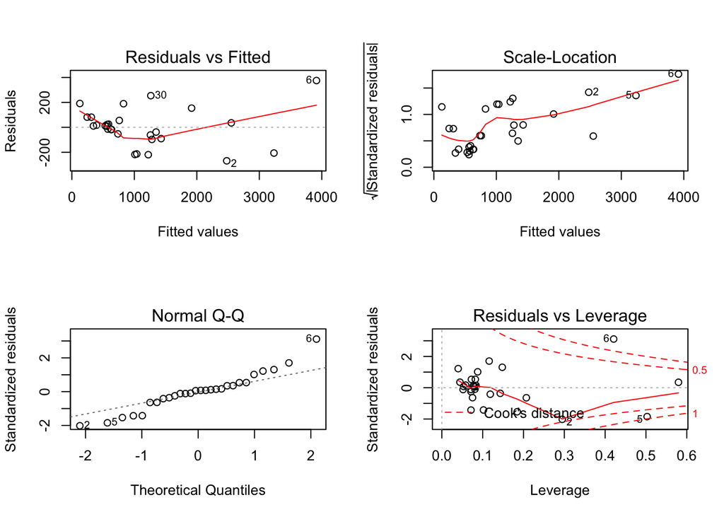

```r
par(mfcol=c(2, 2))
plot(regm)
```

The only weird thing is the theoretical quantiles of the normal distribution. As previously we see extrema deviating from the theoretical line.

The surprisingly low coefficient associated to MOB (surprised according to what we saw just before) can be explained according to me by the fact that it’s very correlated to HIP, meaning that it do not add much more information than HIP. As such we can probably remove it without impacting significantly the results.

```r
reg0 <- lm(BRW~1, data = phyto)
step(reg0, scope=BRW~AUD + MOB + HIP, direction='forward')
```

```
## Start:  AIC=433.88
## BRW ~ 1
##
##        Df Sum of Sq      RSS    AIC
## + HIP   1  73272731 11869487 378.74
## + MOB   1  66447848 18694370 391.92
## + AUD   1  23770396 61371823 426.39
## <none>              85142218 433.88
##
## Step:  AIC=378.74
## BRW ~ HIP
##
##        Df Sum of Sq      RSS    AIC
## + MOB   1   2846939  9022548 372.79
## + AUD   1   2013783  9855704 375.35
## <none>              11869487 378.74
##
## Step:  AIC=372.79
## BRW ~ HIP + MOB
##
##        Df Sum of Sq     RSS    AIC
## + AUD   1   1910121 7112426 367.89
## <none>              9022548 372.79
##
## Step:  AIC=367.89
## BRW ~ HIP + MOB + AUD
```

```
##
## Call:
## lm(formula = BRW ~ HIP + MOB + AUD, data = phyto)
##
## Coefficients:
## (Intercept)          HIP          MOB          AUD
##    -1003.95        44.35       -29.24        52.82
```

Apparently it constructs several models by adding variables at each step. The AIC measure apparently is better when lower and penalizes adding to much variables without gaining performance. The lower among all models is the one with all considered variables. So according to AIC, we can keep it as such.

# Part 4:

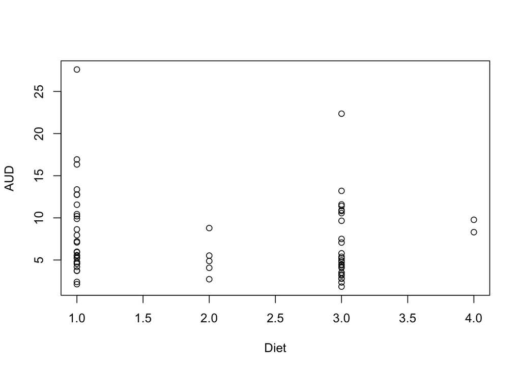

```r
bats$Diet_F <- as.factor(bats$Diet)
with(bats, plot(AUD~Diet))
```

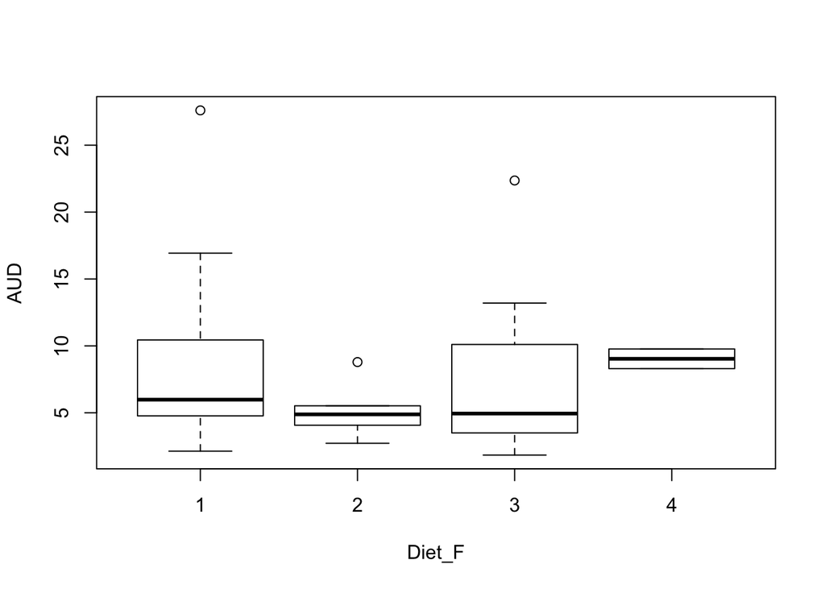

```r
with(bats, plot(AUD~Diet_F))
```

The second one is much more readable because it takes into account the modality of the data. As such, r plot the AUD, which is a quantitative data, using a boxplot. For the first one, it’s just a classical scatter plot. It’s less readable, but it allow us to see samples that are very far from the rest of the distribution

```r
reg = lm(AUD~Diet_F, data=bats)
anova(reg)
```

```
## Analysis of Variance Table
##
## Response: AUD
##           Df  Sum Sq Mean Sq F value Pr(>F)
## Diet_F     3   66.07  22.023  0.9293 0.4323
## Residuals 59 1398.26  23.699
```